# Daily Weather Data

```r
library(GHCNr)
library(terra)  # for handling countries geometries
```

# Select GHCNd stations

The station inventory file of GHCNd is stored at https://www.ncei.noaa.gov/products/land-based-station/global-historical-climatology-network-daily. The function `stations()` can read from this source or from a local file, specified with `filename`. The inventory can also be downloaded to a file using `download_inventory()`.

```r
inventory_file <- download_inventory("~/Downloads/ghcn-inventory.txt")
stations <- stations(inventory_file, variables = "TMAX")
stations
```

```
#> # A tibble: 40,428 × 6
#>    station     latitude longitude variable startYear endYear
#>    <chr>          <dbl>     <dbl> <chr>        <dbl>   <dbl>
#>  1 ACW00011604     17.1     -61.8 TMAX          1949    1949
#>  2 ACW00011647     17.1     -61.8 TMAX          1961    1961
#>  3 AE000041196     25.3      55.5 TMAX          1944    2024
#>  4 AEM00041194     25.3      55.4 TMAX          1983    2024
#>  5 AEM00041217     24.4      54.7 TMAX          1983    2024
#>  6 AEM00041218     24.3      55.6 TMAX          1994    2024
#>  7 AF000040930     35.3      69.0 TMAX          1973    1992
#>  8 AFM00040938     34.2      62.2 TMAX          1973    2020
#>  9 AFM00040948     34.6      69.2 TMAX          1966    2021
#> 10 AFM00040990     31.5      65.8 TMAX          1973    2020
#> # ℹ 40,418 more rows
```

By specifying `variables = "TMAX"` only the stations that recorded that variable are kept. Available variables implemented at the moment are precipitation (“PRCP”), minimum temperature (“TMIN”), and maximum temperature (“TMAX”).

Stations spanning a time range can be filtered easily.

```r
stations <- stations[stations$startYear <= 1990, ]
stations <- stations[stations$endYear >= 2000, ]
stations
```

```
#> # A tibble: 16,763 × 6
#>    station     latitude longitude variable startYear endYear
#>    <chr>          <dbl>     <dbl> <chr>        <dbl>   <dbl>
#>  1 AE000041196     25.3     55.5  TMAX          1944    2024
#>  2 AEM00041194     25.3     55.4  TMAX          1983    2024
#>  3 AEM00041217     24.4     54.7  TMAX          1983    2024
#>  4 AFM00040938     34.2     62.2  TMAX          1973    2020
#>  5 AFM00040948     34.6     69.2  TMAX          1966    2021
#>  6 AFM00040990     31.5     65.8  TMAX          1973    2020
#>  7 AG000060390     36.7      3.25 TMAX          1940    2024
#>  8 AG000060590     30.6      2.87 TMAX          1940    2024
#>  9 AG000060611     28.0      9.63 TMAX          1958    2024
#> 10 AG000060680     22.8      5.43 TMAX          1940    2004
#> # ℹ 16,753 more rows
```

Spatial filters can also be easily applied. Spatial boundaries of countries can be downloaded from https://www.geoboundaries.org/ using the `get_countr(couuntry_code = ...)` function, where `country_code` is the ISO3 code.

```r
italy <- get_country("ITA")
```

`get_countries()` can take several ISO3 codes to return a geometry of multiple countries.

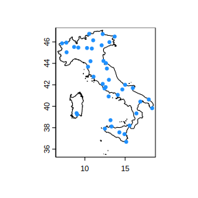

```r
stations <- filter_stations(stations, italy)
plot(italy)
points(stations[, c("longitude", "latitude")], pch = 20, col = "dodgerblue")
```

# Download daily timeseries

Daily timeseries for a station can be downloaded using the `daily()` function. In addition to the station ID, `daily()` needs start and end dates of the timeseries. These should be provided as strings with the format “YYYY-mm-dd”, e.g., “1990-01-01”.

```r
daily_ts <- daily(
  stations$station[1],
  paste("1990", "01", "01", sep = "-"),  # shorten a bit as example
  paste(stations$endYear[1], "12", "21", sep = "-"),
  variables = "tmin"
)
daily_ts
```

```
#> # A tibble: 12,736 × 4
#>    date       station      tmin tmin_flag
#>    <date>     <chr>       <dbl> <chr>
#>  1 1990-01-01 IT000016090  -6.1 ""
#>  2 1990-01-02 IT000016090  -5.2 ""
#>  3 1990-01-03 IT000016090  -6.7 ""
#>  4 1990-01-04 IT000016090  -7   ""
#>  5 1990-01-05 IT000016090  -7.2 ""
#>  6 1990-01-06 IT000016090  -6.1 ""
#>  7 1990-01-07 IT000016090  -6   ""
#>  8 1990-01-08 IT000016090  -9   ""
#>  9 1990-01-09 IT000016090  -5   ""
#> 10 1990-01-10 IT000016090  -5.1 ""
#> # ℹ 12,726 more rows
```

Implmented variables are “tmin”, “tmax”, and “prcp”. `daily()` returns a table with the value of the variable chosen and associated flags. Only certain flags from GHCNd are implemented, namely:

```
#>                D                I           K         M           N
#> 1 duplicate flag consistency flag streak flag mega flag naught flag
#>                   R
#> 1 lagged range flag
```

Flagged records can be removed using `remove_flagged(). This will also remove the "*_flag=" column.

```r
daily_ts <- remove_flagged(daily_ts)
```

```
#> Removing 3 flagged record(s):
#>  - 3 consistency flag(s)
```

```r
daily_ts
```

```
#> # A tibble: 12,733 × 3
#>    date       station      tmin
#>    <date>     <chr>       <dbl>
#>  1 1990-01-01 IT000016090  -6.1
#>  2 1990-01-02 IT000016090  -5.2
#>  3 1990-01-03 IT000016090  -6.7
#>  4 1990-01-04 IT000016090  -7
#>  5 1990-01-05 IT000016090  -7.2
#>  6 1990-01-06 IT000016090  -6.1
#>  7 1990-01-07 IT000016090  -6
#>  8 1990-01-08 IT000016090  -9
#>  9 1990-01-09 IT000016090  -5
#> 10 1990-01-10 IT000016090  -5.1
#> # ℹ 12,723 more rows
```

Coverage of the timeseries can be calculated using `daily_coverage()`.

```r
coverage <- daily_coverage(daily_ts)
```

```r
coverage[coverage$monthly_coverage < 1, ]
```

```
#> # A tibble: 152 × 6
#>    station      year month monthly_coverage annual_coverage year_coverage
#>    <chr>       <dbl> <dbl>            <dbl>           <dbl>         <dbl>
#>  1 IT000016090  1998    12            0.581           0.964         0.914
#>  2 IT000016090  1999     4            0.7             0.833         0.914
#>  3 IT000016090  1999     5            0.645           0.833         0.914
#>  4 IT000016090  1999     6            0.867           0.833         0.914
#>  5 IT000016090  1999     7            0.774           0.833         0.914
#>  6 IT000016090  1999     8            0.742           0.833         0.914
#>  7 IT000016090  1999     9            0.933           0.833         0.914
#>  8 IT000016090  1999    10            0.774           0.833         0.914
#>  9 IT000016090  1999    11            0.7             0.833         0.914
#> 10 IT000016090  1999    12            0.871           0.833         0.914
#> # ℹ 142 more rows
```

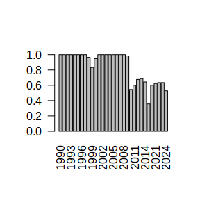

```r
with(coverage[coverage$month == 1, ],
  barplot(
    annual_coverage,
    names.arg = year,
    las = 2
  )
)
```

Note that missing years are not shown and that `year_coverage` only calculates the number of years that have been covered, not their internal coverage.

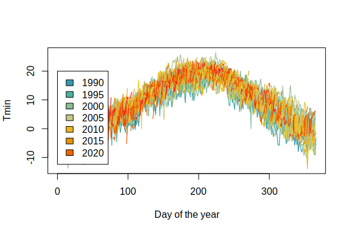